Skip to main content

CSIS Australia Chair

# U.S.-Australia Economic Dashboard

Australia is often said to rely on China for prosperity and the U.S. for security, but that holds only for goods trade: count services, investment, intellectual property and technology, and the U.S. is Australia’s most important economic partner as well as its closest ally. Data on the U.S.-Australia economic relationship are scattered across more than 20 institutions in the two countries; this dashboard brings them together in one regularly updated view, built entirely from official U.S. and Australian data. Hover over any chart for exact values. Author contact information

Updated 27 November 2026 · Next update December 2026

## Key Figures

The U.S. is Australia’s **#1** services trading partner

The U.S. is Australia’s **#2** goods trading partner

The U.S. runs a **A$39bn** trade surplus with Australia

The U.S. is Australia’s largest foreign investor, investing **A$1.4tn**

The U.S. is the largest destination for Australian investment abroad, at **A$1.6tn**

The U.S. is the largest patent filer in Australia, with **41%** of applications

## Explore the Relationship

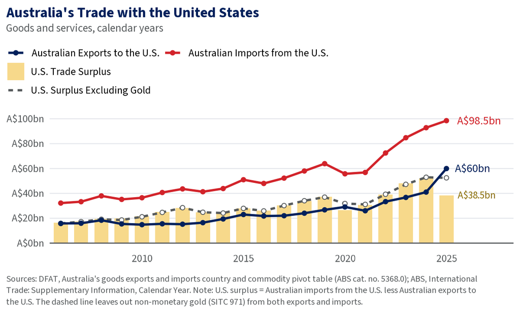

Trade Overview

EXPLORE →

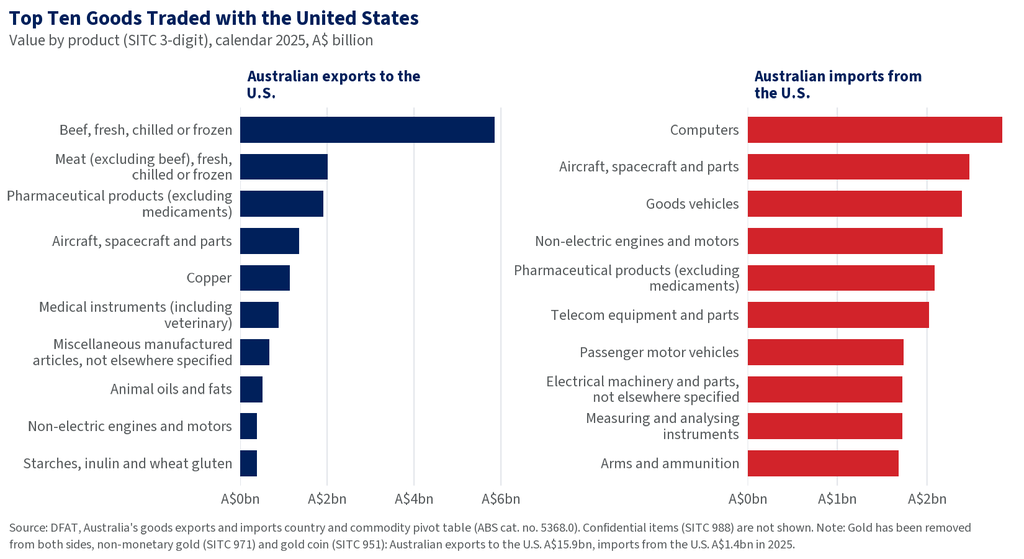

Trade in Goods

EXPLORE →

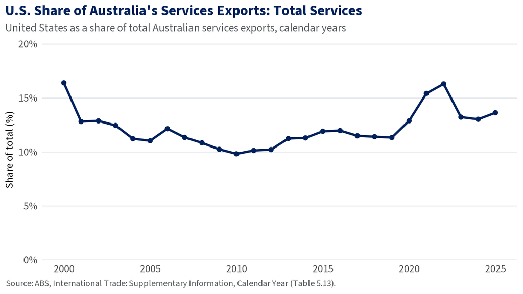

Trade in Services

EXPLORE →

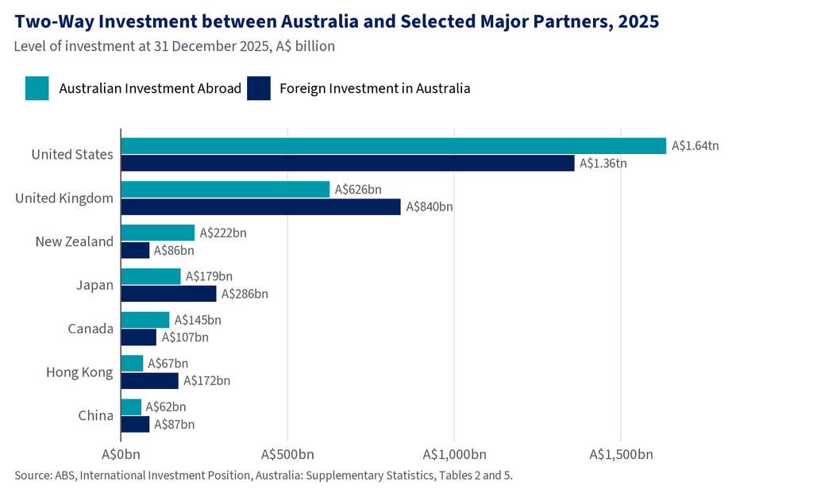

Foreign Investment

EXPLORE →

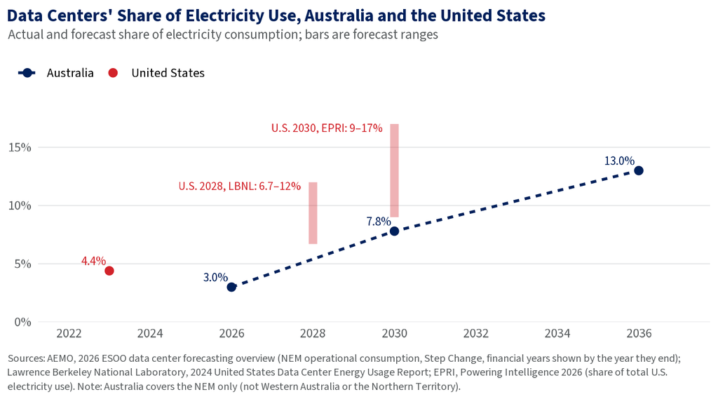

Data Centers

EXPLORE →

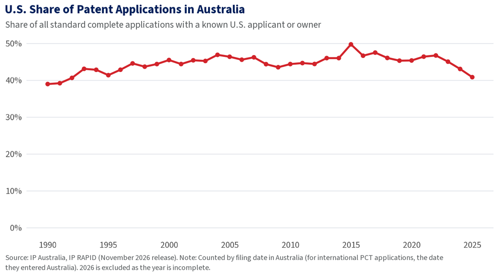

Intellectual Property

EXPLORE →

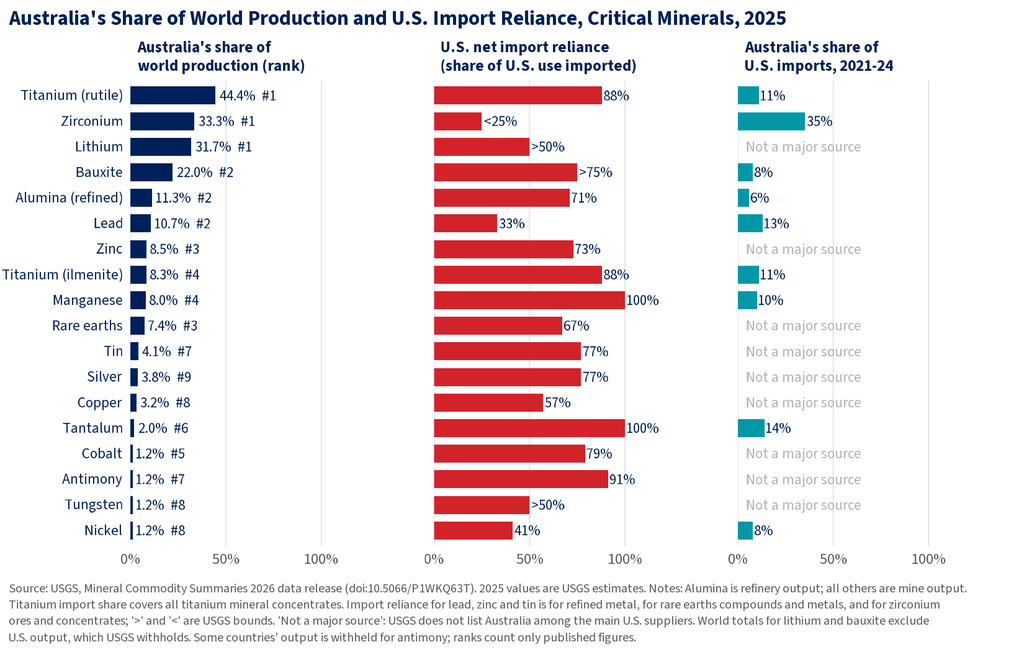

Critical Minerals

EXPLORE →

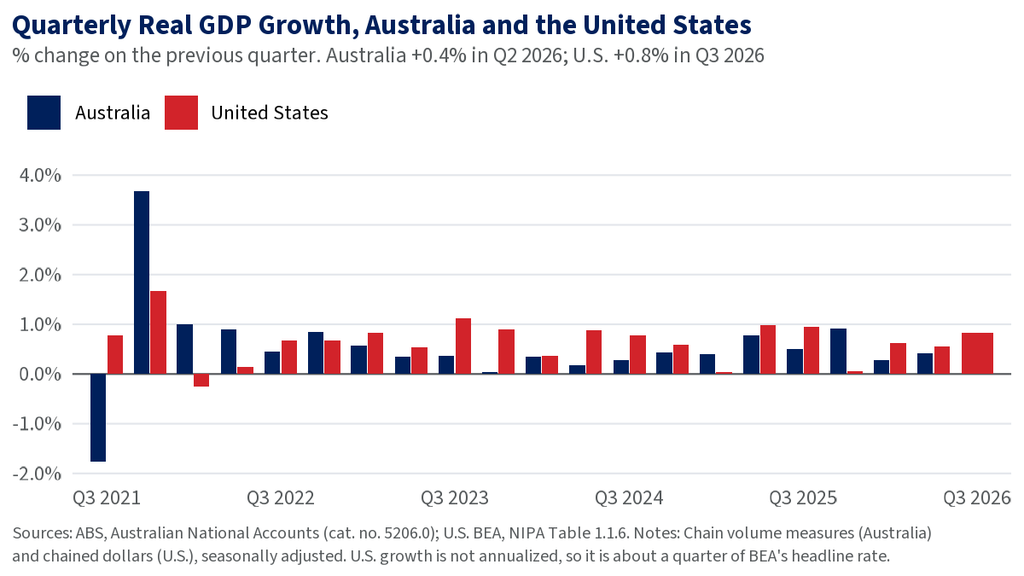

Economic Indicators

EXPLORE →

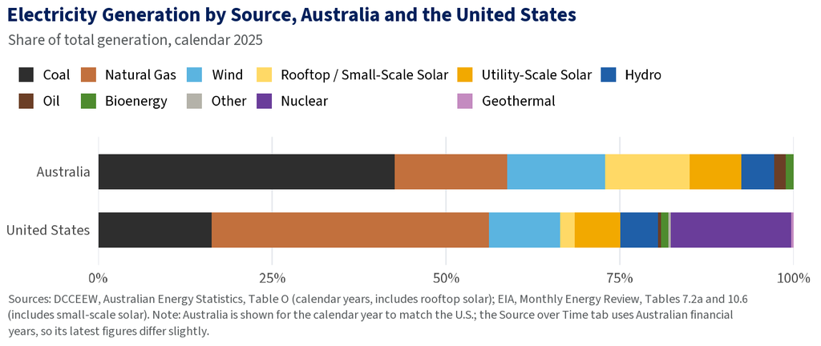

Energy

EXPLORE →

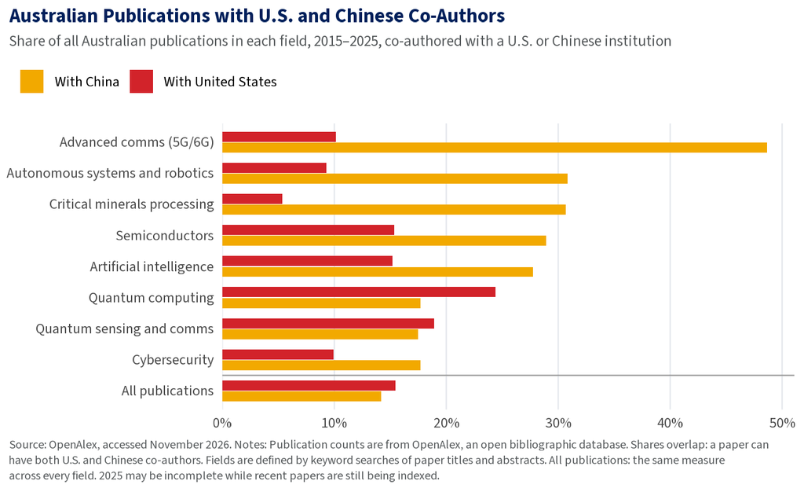

Research and AI

EXPLORE →

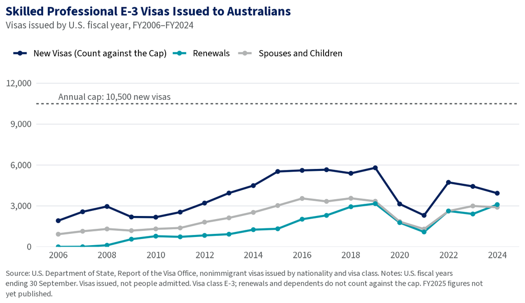

Human Capital

EXPLORE →

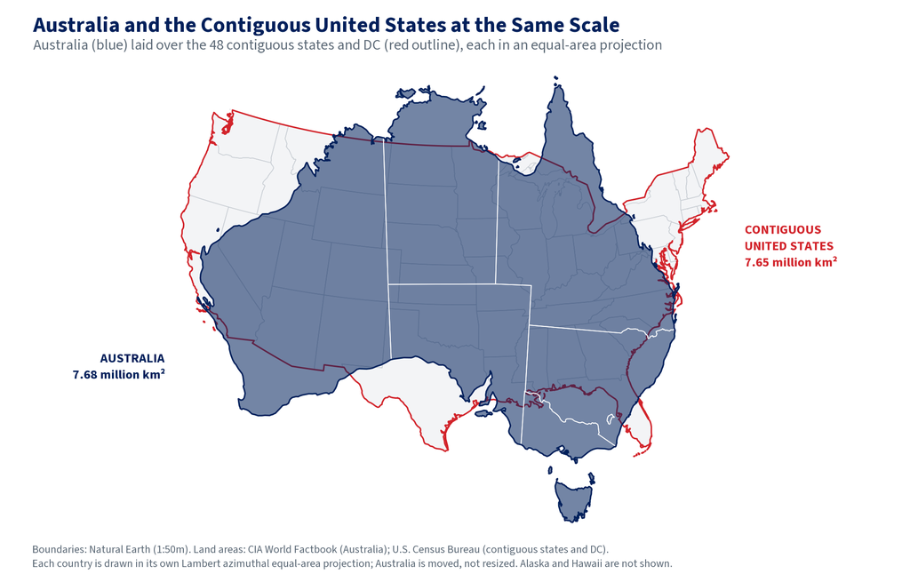

Geography

EXPLORE →

Australia's Trade by Partner

**Goods**

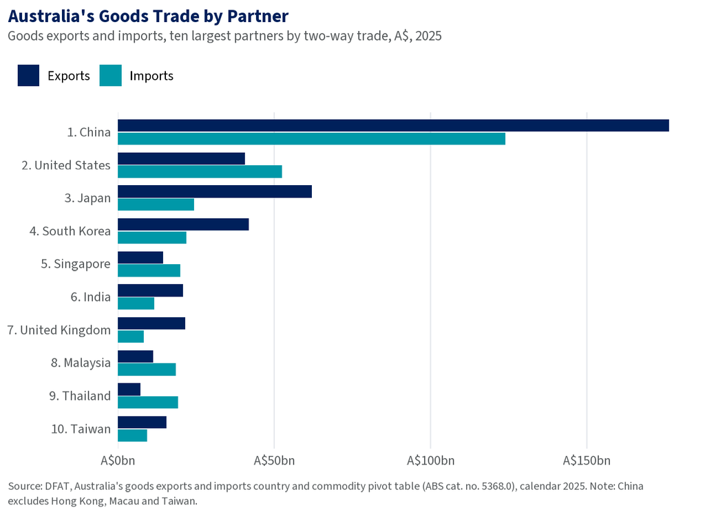

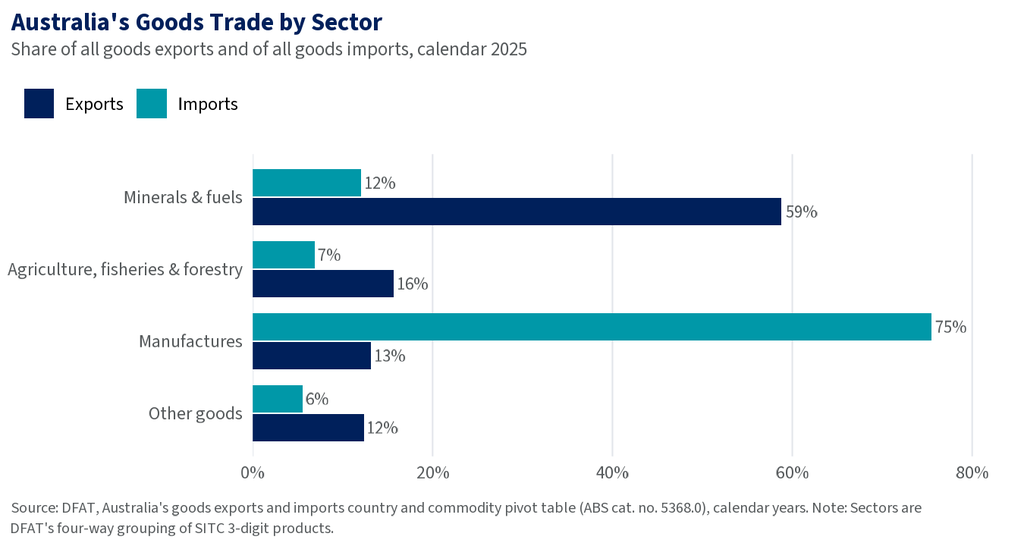

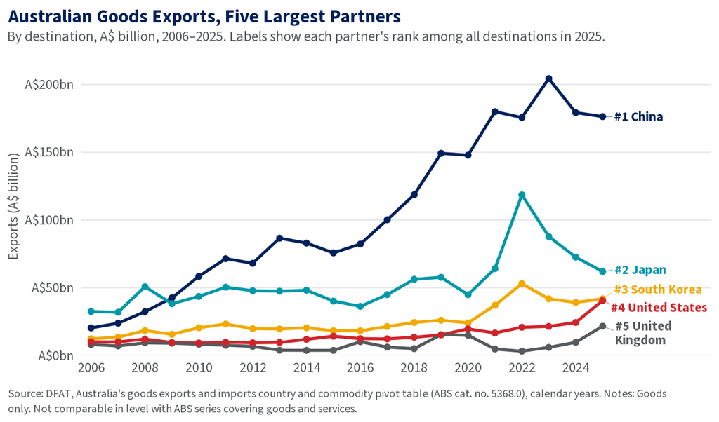

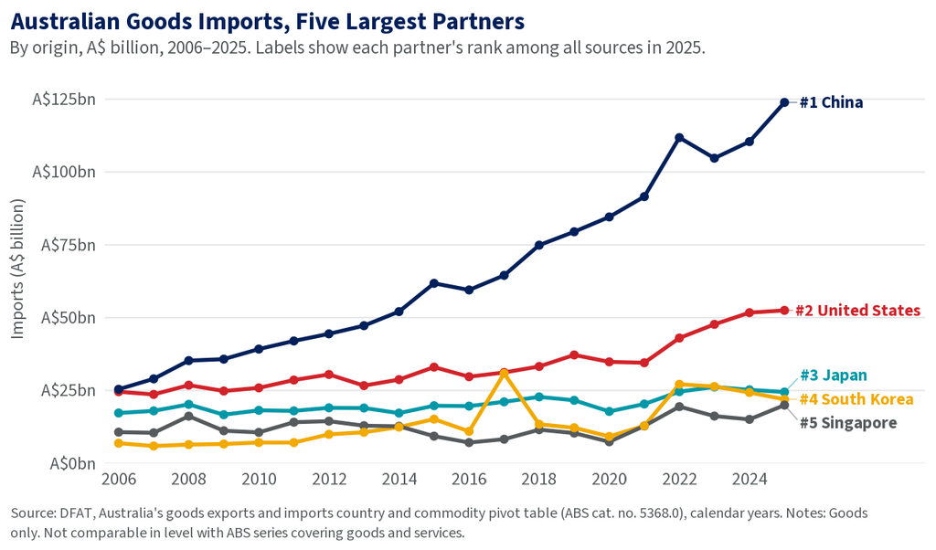

**Services**

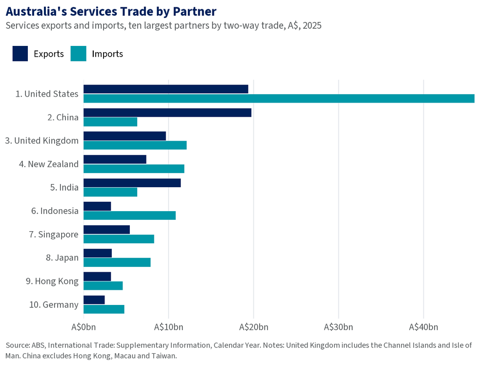

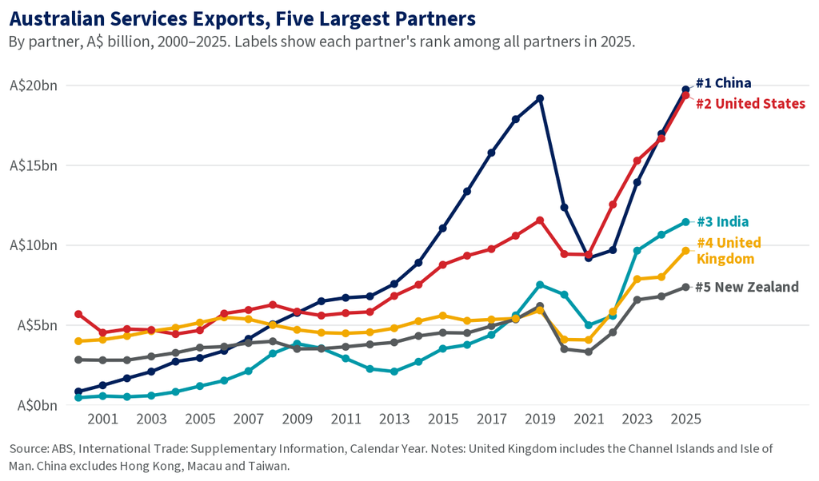

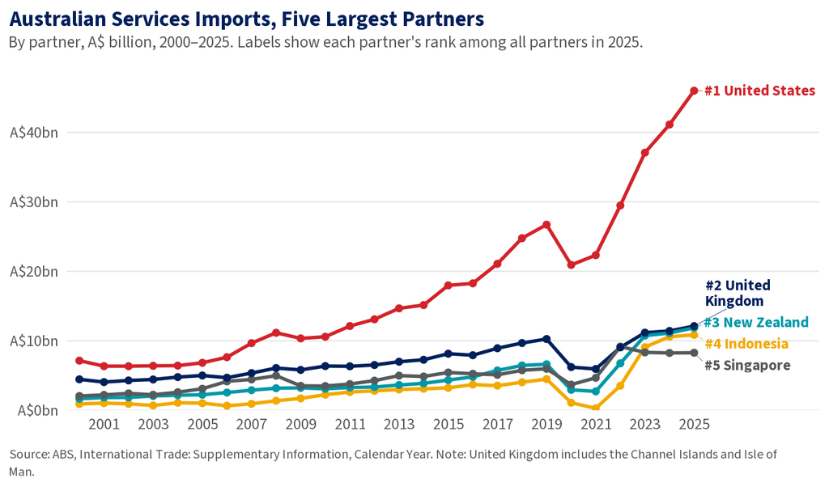

U.S. Trade Balance with Australia, by Year

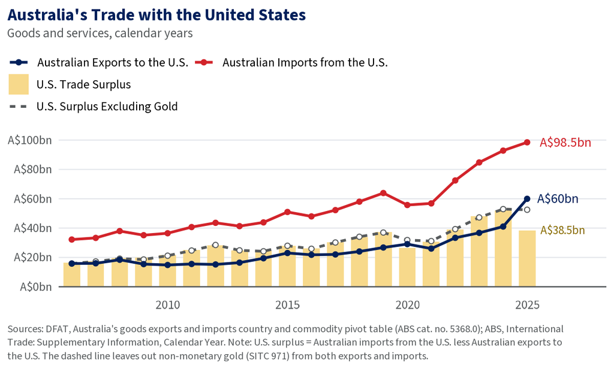

U.S. Trade Balance with Australia, by Quarter

**Goods**

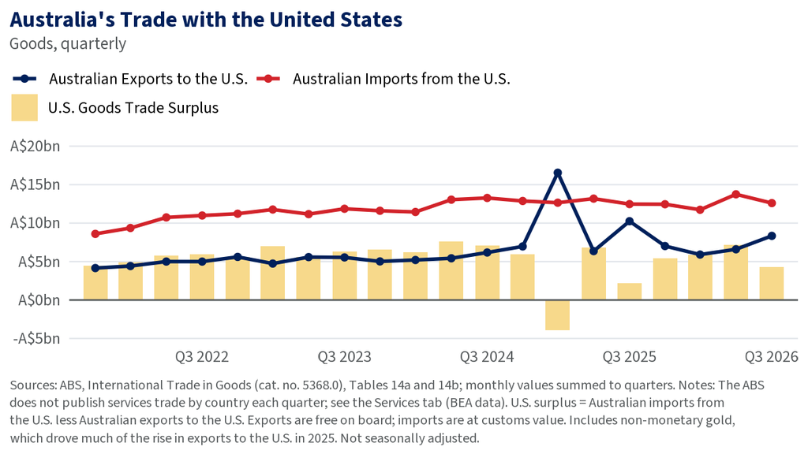

**Services**

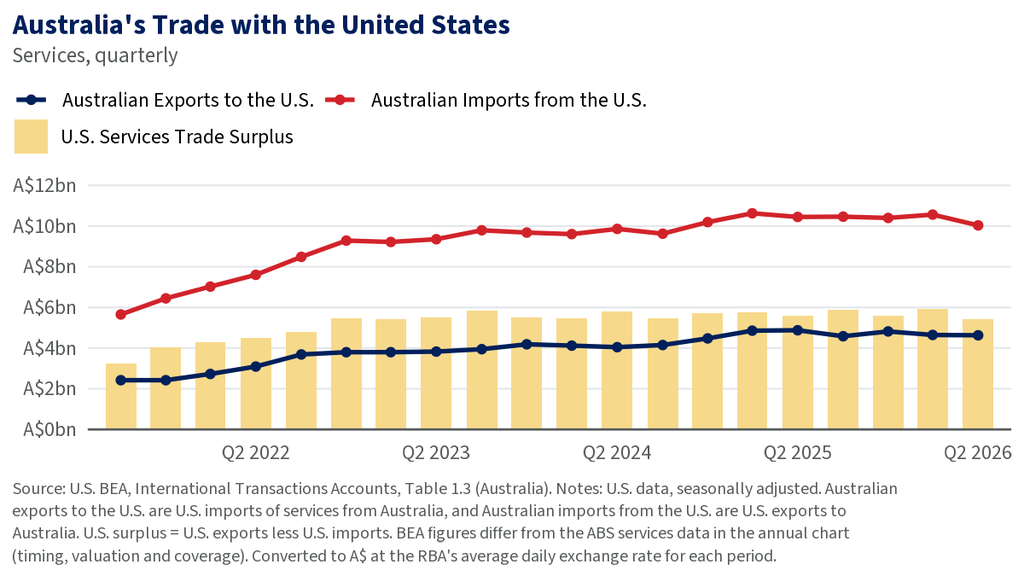

Goods Traded with the U.S.

**Top Ten Products**

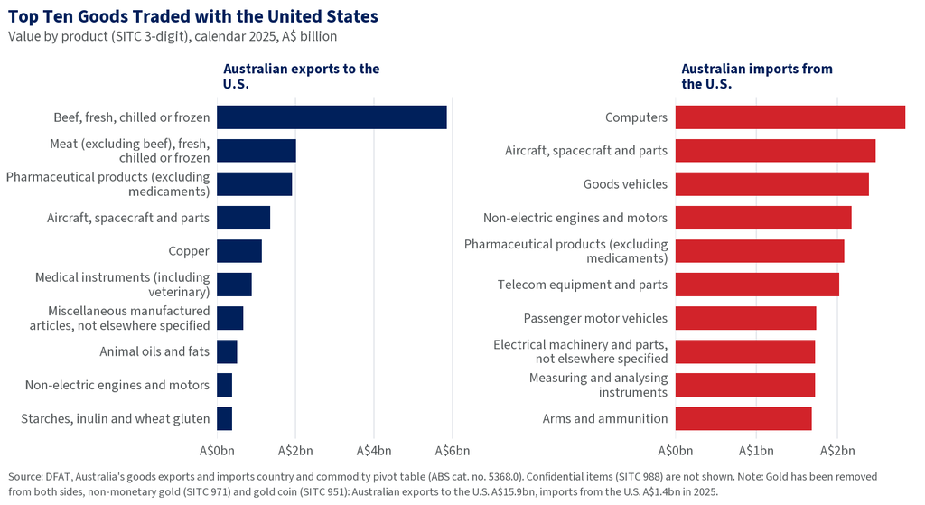

**All Products**

Goods Trade by Product with the U.S.

[figure not shown]

Services Traded with the U.S.

[figure not shown]

No chart for this service in this direction.

Australia's International Investment

**By Partner**

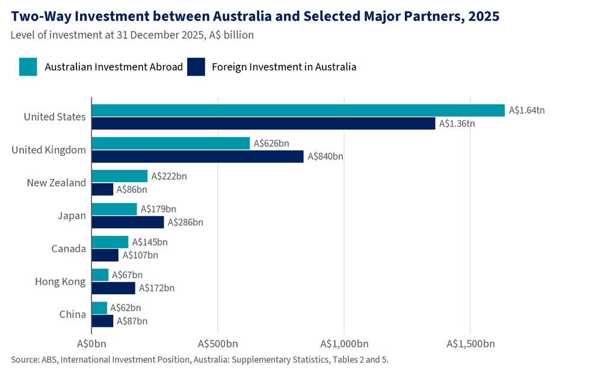

**By Type of Investment**

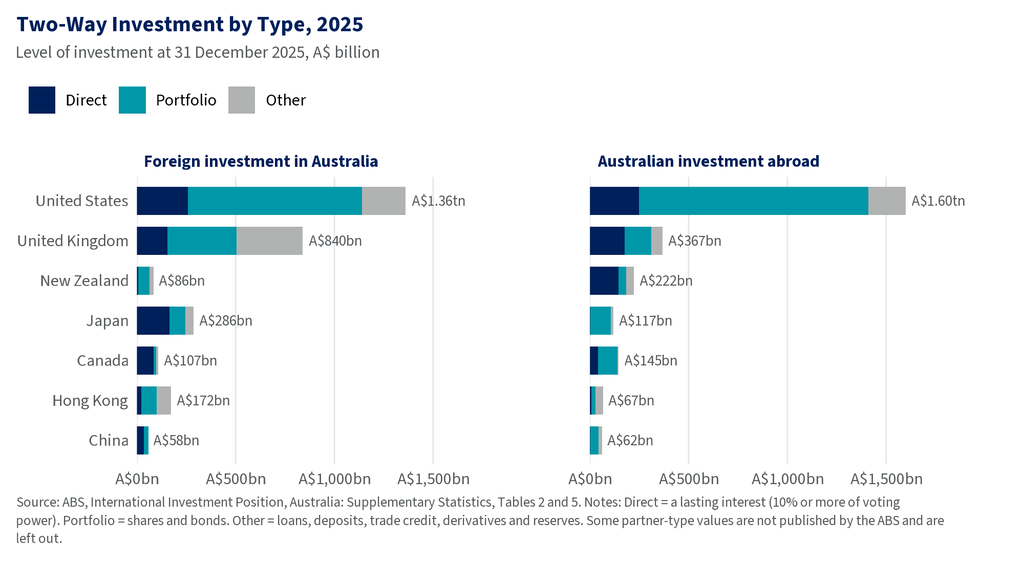

**By Industry**

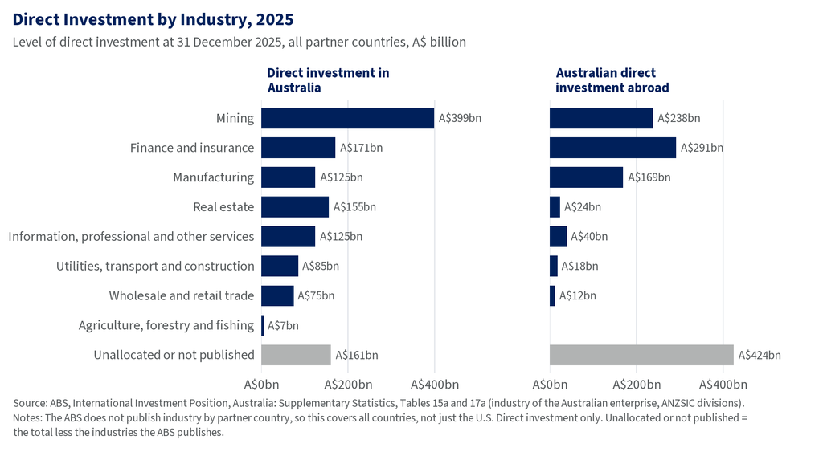

U.S.-Australia Direct Investment Flows, by Quarter

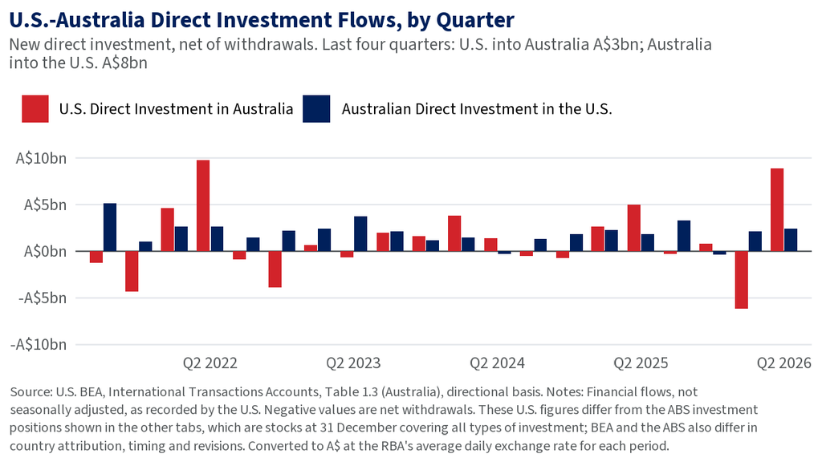

Data Centers' Share of Electricity Use

**Australia and the U.S.**

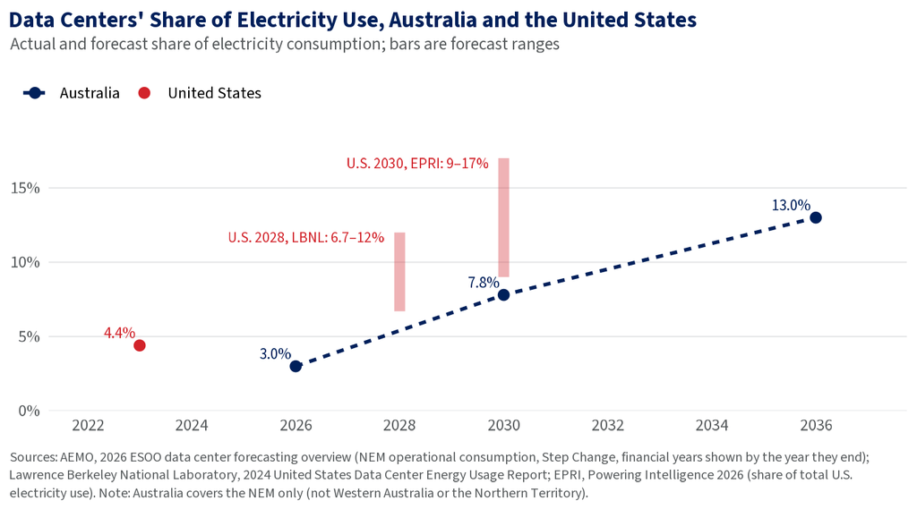

Australian Investment in Data Centers

**Capital Investment**